# Unsupervised Learning: Trade&Ahead

```python
subset_scaled_df["HC_Clusters"] = HCModel.labels_
df["HC_Clusters"] = HCModel.labels_
```

```python
for cl in df["HC_Clusters"].unique():
    print("In cluster {}, the following countries are present:".format(cl))
    print(df[subset_scaled_df["HC_Clusters"] == cl]["Security"].unique())
    print()
```

```
In cluster 2, the following countries are present:
['American Airlines Group' 'AbbVie' 'Abbott Laboratories'
 'American International Group, Inc.' 'American Express Co'
 'Bank of America Corp' 'The Bank of New York Mellon Corp.'
 'Citigroup Inc.' 'Capital One Financial' 'CVS Health' 'Chevron Corp.'
 'Delta Air Lines' 'Danaher Corp.' 'The Walt Disney Company' 'Duke Energy'
 'Eaton Corporation' 'Ford Motor' 'Gilead Sciences' 'General Motors'
 'Intel Corp.' 'JPMorgan Chase & Co.' 'Coca Cola Company'
 'Lilly (Eli) & Co.' 'Mastercard Inc.' "McDonald's Corp."
 'Mondelez International' 'MetLife Inc.' 'Altria Group Inc' 'Merck & Co.'
 'PepsiCo Inc.' 'Pfizer Inc.' 'Philip Morris International'
 'Prudential Financial' 'AT&T Inc' 'Texas Instruments'
 'United Continental Holdings' 'United Health Group Inc.' 'Union Pacific'
 'United Parcel Service' 'United Technologies' 'Verizon Communications'
 'Wells Fargo' 'Exxon Mobil Corp.']

In cluster 1, the following countries are present:
['Adobe Systems Inc' 'Analog Devices, Inc.' 'Alexion Pharmaceuticals'
 'Amgen Inc' 'Amazon.com Inc' 'Broadcom' 'Celgene Corp.'
 'Charter Communications' 'Chipotle Mexican Grill' 'Equinix'
 'Edwards Lifesciences' 'Facebook' 'First Solar Inc'
 'Intuitive Surgical Inc.' 'Regeneron' 'TripAdvisor'
 'Vertex Pharmaceuticals Inc' 'Waters Corporation' 'Wynn Resorts Ltd']

In cluster 0, the following countries are present:
['Archer-Daniels-Midland Co' 'Alliance Data Systems' 'Ameren Corp'
 'American Electric Power' 'AFLAC Inc' 'Apartment Investment & Mgmt'
 'Assurant Inc' 'Arthur J. Gallagher & Co.' 'Akamai Technologies Inc'
 'Albemarle Corp' 'Alaska Air Group Inc' 'Allstate Corp' 'Allegion'
 'Applied Materials Inc' 'AMETEK Inc' 'Affiliated Managers Group Inc'
 'Ameriprise Financial' 'American Tower Corp A' 'AutoNation Inc'
 'Anthem Inc.' 'Aon plc' 'Amphenol Corp' 'Arconic Inc'
 'Activision Blizzard' 'AvalonBay Communities, Inc.'
 'American Water Works Company Inc' 'Boeing Company'
 'Baxter International Inc.' 'BB&T Corporation' 'Bard (C.R.) Inc.'
 'Baker Hughes Inc' 'BIOGEN IDEC Inc.' 'Ball Corp' 'Bristol-Myers Squibb'
 'Boston Scientific' 'BorgWarner' 'Boston Properties' 'Caterpillar Inc.'
 'Chubb Limited' 'CBRE Group' 'Crown Castle International Corp.'
 'Carnival Corp.' 'CF Industries Holdings Inc' 'Citizens Financial Group'
 'Church & Dwight' 'C. H. Robinson Worldwide' 'CIGNA Corp.'
```

[output cut: 60 more lines]

```
 'Valero Energy' 'Vulcan Materials' 'Vornado Realty Trust'
 'Verisk Analytics' 'Verisign Inc.' 'Ventas Inc' 'Wec Energy Group Inc'
 'Whirlpool Corp.' 'Waste Management Inc.' 'Western Union Co'
 'Weyerhaeuser Corp.' 'Wyndham Worldwide' 'Xcel Energy Inc' 'XL Capital'
 'Dentsply Sirona' 'Xerox Corp.' 'Xylem Inc.' 'Yahoo Inc.'
 'Yum! Brands Inc' 'Zimmer Biomet Holdings' 'Zions Bancorp' 'Zoetis']

In cluster 3, the following countries are present:
['Apache Corporation' 'Anadarko Petroleum Corp' 'Chesapeake Energy'
 'Cabot Oil & Gas' 'Devon Energy Corp.' 'EOG Resources'
 'Freeport-McMoran Cp & Gld' 'Kinder Morgan' 'Marathon Oil Corp.'
 'Murphy Oil' 'Noble Energy Inc' 'Newfield Exploration Co'
 'National Oilwell Varco Inc.' 'ONEOK' 'Occidental Petroleum'
 'Range Resources Corp.' 'Spectra Energy Corp.' 'Southwestern Energy'
 'Teradata Corp.' 'Williams Cos.' 'Cimarex Energy']
```

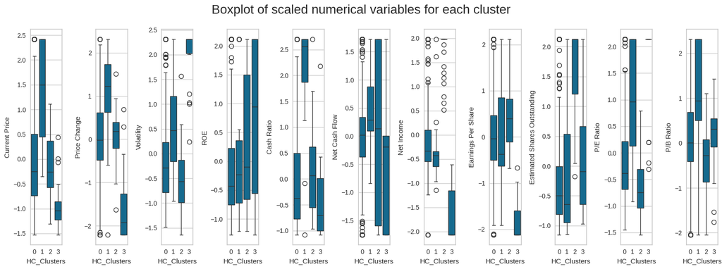

```python
fig, axes = plt.subplots(1, 11, figsize=(16, 6))
fig.suptitle("Boxplot of scaled numerical variables for each cluster", fontsize=20)
counter = 0
for i in range(11):
    sns.boxplot(
        ax=axes[i],
        y=subset_scaled_df[num_col[counter]],
        x=subset_scaled_df["HC_Clusters"],
    )
    counter = counter + 1

fig.tight_layout()
```

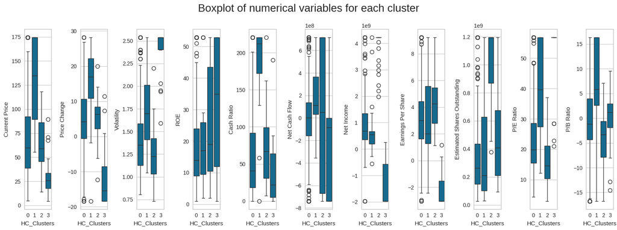

```python
fig, axes = plt.subplots(1, 11, figsize=(16, 6))
fig.suptitle("Boxplot of numerical variables for each cluster", fontsize=20)
counter = 0
for i in range(11):
    sns.boxplot(
        ax=axes[i],
        y=df[num_col[counter]],
        x=df["HC_Clusters"],
    )
    counter = counter + 1

fig.tight_layout()
```

This time there are more clusters. Cluster 1 seems to have the highest current price and the highest price change, but also pretty high volatility.

## Actionable Insights and Recommendations

- Based on clustering done above, investors are recommended to use the clusters generated by the k means method. This is because there are less clusters than the hierarchical method and therefore a higher selection of companies to choose from. Furthermore, the clusters in the k means method seem to have better consistency in how they compare average values. In other words, if a certain cluster has a higher mean price than the other clusters, it might have a higher mean for other measures as well. Therefore an investor can make a big investment, but they can also expect that it can return, and with less volatility of stock price.